# Pre-processing

```r
#load necessary libraries
library(rms)
library(limma)
library(edgeR)
library(tidyverse)
library(dplyr)
library(magrittr)
library(stringr)
#load QC script
source("bulkRNA_QC.R")
```

Now that we’ve loaded in the necessary libraries we want to load in the raw count matrices and phenotype data for each of our cohorts from the Accelerating Medicines Partnership - Alzheimer’s Disease (AMP-AD) consortium. There are three bulk-tissue RNAseq datasets, which sample from 6 different brain regions. The cohorts are the Religious Orders Study and Rush Memory and Aging Project cohort (delineated ROSMAP from here on) which has dorsolateral prefrontal cortex samples, the Mayo Clinic cohort, hereafter referred to as MAYO, which consists of temporal cortex samples and the Mount Sinai Brain Bank cohort (referred to as MSBB), which has expression data sampled from Brodmann area 10, 22, 36 and 44 (written BM10, BM22, BM36, BM44 hereafter).

```r
#function to create YDGE objects for each cohort in the study
createYDGEAMPAD <- function(cohort){
  setwd('./rawCohortData')
  if (cohort == "ROSMAP"){
    filename <- "ROSMAP_all_counts_matrix.txt.gz"
  }
  if(cohort =="MAYO"){
    filename <- "Mayo_TCX_all_counts_matrix.txt.gz"
  }
  if(cohort == "MSBB"){
    filename <- "MSSM_all_counts_matrix.txt.gz"
  }
  all_counts <- read.table(gzfile(filename),sep="\t")
  setwd('../')

  colnames(all_counts) <- as.character(unlist(all_counts[1,]))
  all_counts <- all_counts[-c(1:5),]
  rownames(all_counts) <- gsub('\\.[0-9]*$', '', all_counts$feature)
  counts <- all_counts[,-1]

  counts[] <- lapply(counts, as.numeric)

  if(cohort == "ROSMAP"){
    # read in phenotype/covariate data
    setwd('./cohortMetadata')
    pdata <- read.table("ageCensoredCovariates.tsv", sep="\t",header=T,check.names = F,stringsAsFactors = F)
    setwd('../')
    rownames(pdata) <- pdata$SampleID
    subjects_to_include <- pdata$SampleID
  }
  if(cohort == "MAYO"){
    # read in phenotype/covariate data
    setwd('./cohortMetadata')
    pdata <- read.table("MAYO_CBE_TCX_Covariates.tsv", sep="\t",header=T,check.names = F,stringsAsFactors = F)
    setwd('../')
    # Keep only AD cases and controls
    rownames(pdata) <- pdata$SampleID
    subjects_to_include <- pdata$SampleID[which(pdata$Tissue.Diagnosis %in% c("TCX.AD","TCX.CONTROL"))]
  }
  if (cohort == "MSBB"){
    # read in phenotype/covariate data
    setwd('./cohortMetadata')
    pdata <- read.table("MSBB_RNAseq_covariates_November2018Update.csv", sep=",",header=T,check.names = F,stringsAsFactors = F)

    # "BM_22_", "BM_36_", "BM_10_", "BM_44" are 4 brodmann areas of msbb
    phenodata <- read.table("msbb_individual_metadata.csv", sep=",",header=T,check.names = F,stringsAsFactors = F)
    phenodata <- phenodata %>%
      dplyr::rename(
        individualIdentifier = individualID,
      )
    pdata <- merge(pdata, phenodata, by="individualIdentifier")
    #remove 272 samples as specified in syn8484987
    samples<- read.table("removesinai.txt", sep=",",header=T,check.names = F,stringsAsFactors = F)
    for (sample in colnames(samples)){
      pdata <- subset(pdata,
                      sampleIdentifier != sample)
    }
    setwd('../')
    #create diagnosis variable as specified in syn8484987
    pdata$Diagnosis = 'OTHER'
    #HAD TO MOD FROM OG CODE: NP.1 is now CERAD, bbscore is now Braak
    pdata$Diagnosis[pdata$CDR <= 0.5 & pdata$Braak <= 3 & pdata$CERAD <= 1] = 'CONTROL'
    pdata$Diagnosis[pdata$CDR >= 1 & pdata$Braak >= 4 & pdata$CERAD >= 2] = 'AD'
    pdata$Tissue.Diagnosis = paste(pdata$Tissue, pdata$Diagnosis, sep = '.')

    rownames(pdata) <- make.names(pdata$sampleIdentifier, unique= TRUE)
    MSBBs <- c("MSBBBM10", "MSBBBM22", "MSBBBM36", "MSBBBM44")
    #taking overlap of subjects described in each brodman area and found in all_countsmatrix, some
    #samples described in msbb_individual_metadata.csv not found in all_countsmatrix
    for(MSBB in MSBBs){
      region <- gsub('MSBB', '', MSBB)
      subjects_to_include <- unique(pdata$sampleIdentifier[which(pdata$BrodmannArea %in% c(region))])
      subjects_to_include <- intersect(colnames(counts),subjects_to_include)
      region_name <- paste0(region, "subjects_to_include")
      print(region_name)
      assign(region_name, subjects_to_include)
      if(region == "BM10"){
        subs <- data.frame("sampleIdentifier" = subjects_to_include)
      }
      else{
        curr_subs <- data.frame("sampleIdentifier" = subjects_to_include)
        subs <- rbind(subs, curr_subs)
      }

    }
    idsAcross <- data.frame("sampleIdentifier" = pdata$sampleIdentifier, "individualIdentifier" = pdata$individualIdentifier)
    allMSBBsubs <- subs
    MSBBIDsAcross <-  inner_join(allMSBBsubs, idsAcross)
    setwd('./rawCohortData')
    saveRDS(MSBBIDsAcross, "allMSBBIDs.rds")
    setwd('../')
  }
  if(cohort == "ROSMAP" | cohort=="MAYO"){
    cohort_ydge_name <-  paste0(cohort, "ydge")
    ydge <- DGEList(counts=counts[,subjects_to_include],
                    lib.size=colSums(counts[,subjects_to_include]),
                    samples=pdata[subjects_to_include,],
                    group=pdata[subjects_to_include,"Source"])
    print(cohort_ydge_name)
    assign(cohort_ydge_name, ydge)
    setwd('./rawYDGE')
    saveRDS(ydge, file=paste0("raw_", cohort_ydge_name, ".rds"))
    setwd('../')
  }
  else{
    for(MSBB in MSBBs){
      region <- gsub('MSBB', '', MSBB)
      region_name <- paste0(region, "subjects_to_include")
      ydge <- DGEList(counts=counts[,get(region_name)],
                      lib.size=colSums(counts[,get(region_name)]),
                      samples=pdata[get(region_name),],
                      group=pdata[get(region_name),"Source"])
      region_ydge_name <- paste0(region, "ydge")
      print(region_ydge_name)
      assign(region_ydge_name, ydge)
      setwd('./rawYDGE')
      saveRDS(ydge, file=paste0("raw_", region_ydge_name, ".rds"))
      setwd('../')
    }

  }
}

#cohorts are split into ROSMAP/MAYO/MSBB
cohorts <- c("ROSMAP", "MAYO", "MSBB")
for(cohort in cohorts){
  createYDGEAMPAD(cohort)
}
```

```
## [1] "ROSMAPydge"
## [1] "MAYOydge"
## [1] "BM10subjects_to_include"
## [1] "BM22subjects_to_include"
## [1] "BM36subjects_to_include"
## [1] "BM44subjects_to_include"
```

```
## [1] "BM10ydge"
## [1] "BM22ydge"
## [1] "BM36ydge"
## [1] "BM44ydge"
```

```r
#load in new cohorts raw ydge created by splitting MSBB into brain regions
cohorts <- c("ROSMAP", "MAYO", "MSBBM10", "MSBBM22", "MSBBM36", "MSBBM44")
for(cohort in cohorts){
  if(str_detect(cohort, "MSBB"))
    {
    cohort <- gsub('MSB', '', cohort)
  }
  print(cohort)
  cohort_ydge_name <-  paste0(cohort, "ydge")
  filename <- paste0("raw_", cohort_ydge_name, ".rds")
  setwd('./rawYDGE')
  raw_ydge <- readRDS(filename)
  setwd('../')
  assign(cohort_ydge_name, raw_ydge)
}
```

```
## [1] "ROSMAP"
## [1] "MAYO"
## [1] "BM10"
## [1] "BM22"
## [1] "BM36"
## [1] "BM44"
```

At the moment each cohort has the following number of subjects:

ROSMAP: 632

MAYO: 151

MSBB BM10: 214

MSBB BM22: 191

MSBB BM36: 162

MSBB BM44: 187

```
## [1] "ROSMAP"
## [1] "Saving input parameters"
## [1] "Removing genes with low absolute counts"
## [1] "Kept 18858 out of 60725 genes after pruning for median raw count."
## [1] "pruning for high expression not performed"
## [1] "pruning for high variance not performed"
## [1] "pruning subjects by PCA according to batch"
```

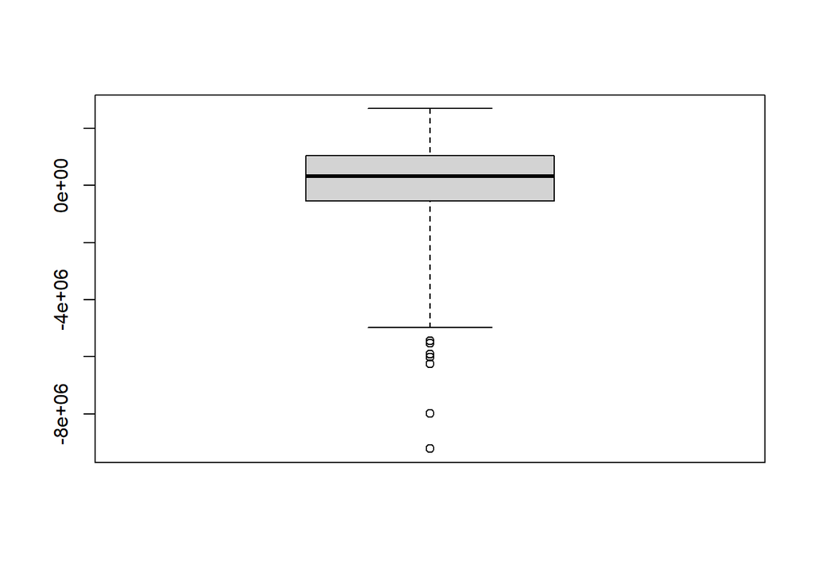

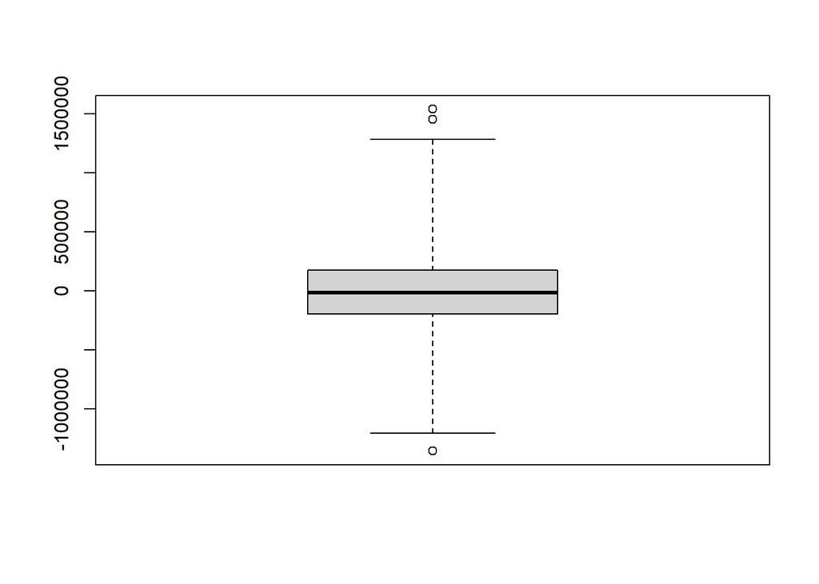

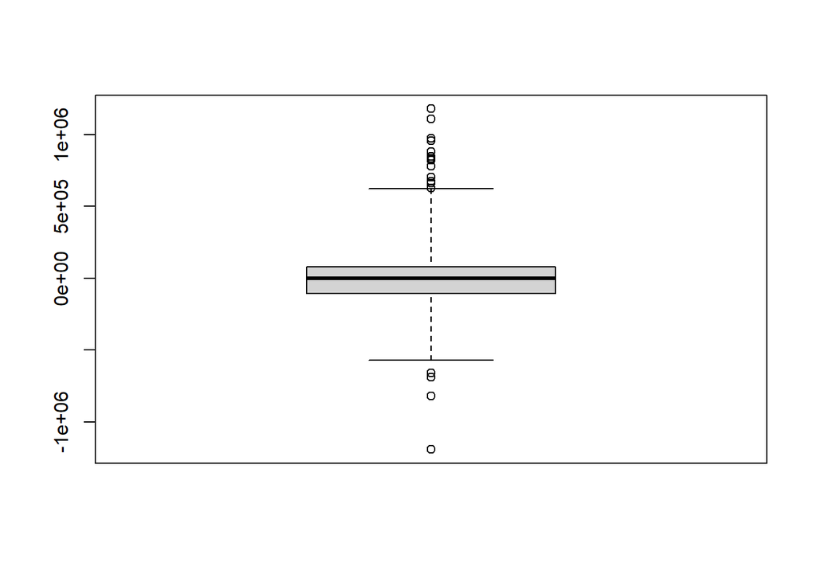

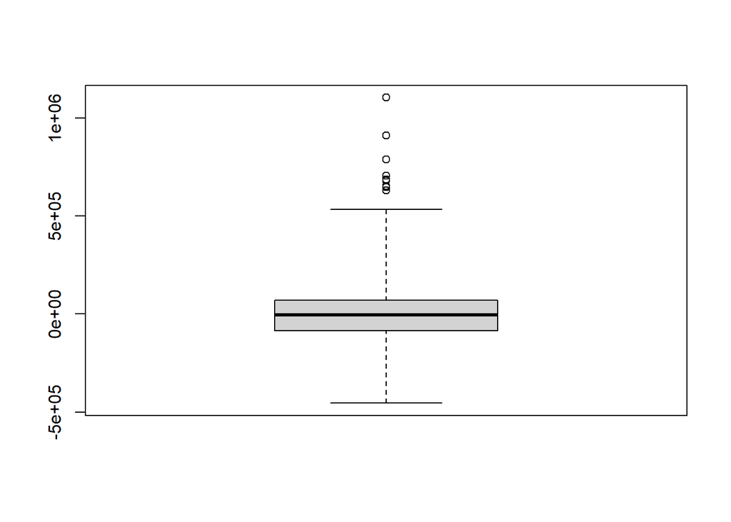

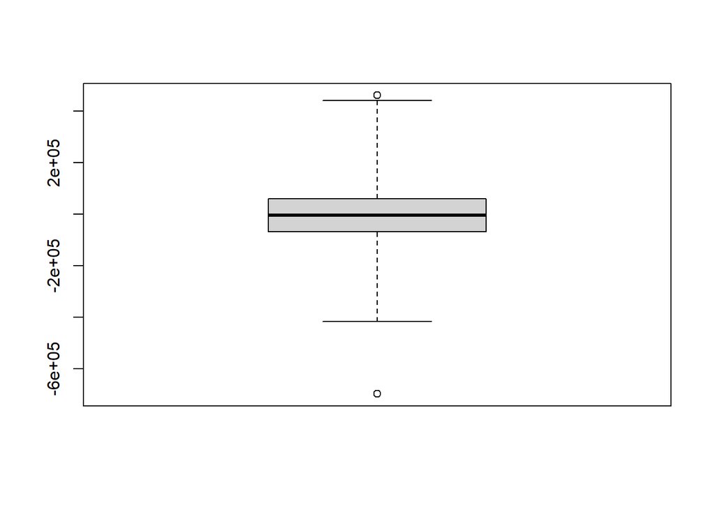

```
## [[1]]
## [1] "Removed 35 subjects: 145_120419, 398_120503, 406_120503, 844_130830, 799_130701, 778_130528, 792_130530, 08_120410, 11_120410, 134_120419, 325_120501, 949_131107, 847_130830, 811_130702, 945_131107, 865_130911, 809_130702, 763_130520, 833_130729, 767_130523, 954_131107, 769_130523, 884_13092…
##
## [[2]]
## [1] "Pre-QC n=632. Post-QC n=597"
##
## [1] "coercing extreme values to max/min indiviually per gene"
## [1] "number of genes detected with >0 low outliers = 3557/18858"
## [1] "number of genes detected with >0 high outliers = 468/18858"
## [1] "number of observations adjusted for low outliers = 1-74. quantiles=1,1,1,4,74"
## [1] "number of observations adjusted for high outliers = 1-14. quantiles=1,1,1,2,14"
## [1] "completed ##------ Mon May 10 11:36:00 2021 ------##"
## [1] "WARNING: DGE object phenotype data contains missing values"
## [1] "QCd_ydge_ROSMAP"
## [1] "v_ROSMAP"
## [1] "MAYO"
## [1] "Saving input parameters"
## [1] "Removing genes with low absolute counts"
## [1] "Kept 19750 out of 60725 genes after pruning for median raw count."
## [1] "pruning for high expression not performed"
## [1] "pruning for high variance not performed"
## [1] "pruning subjects by PCA according to batch"
```

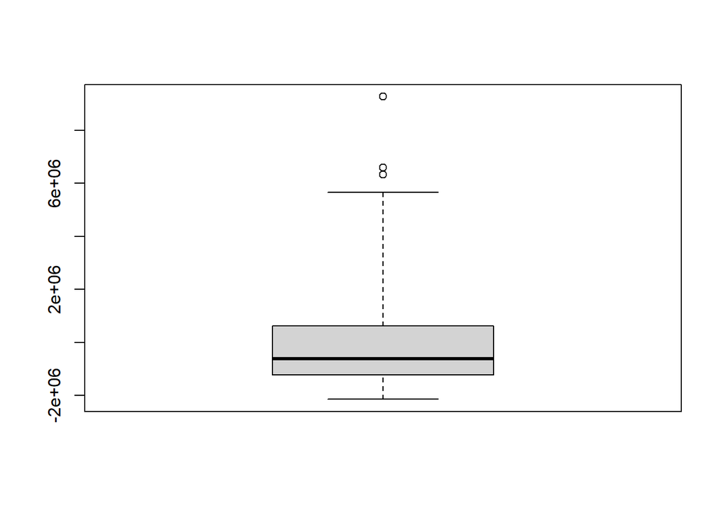

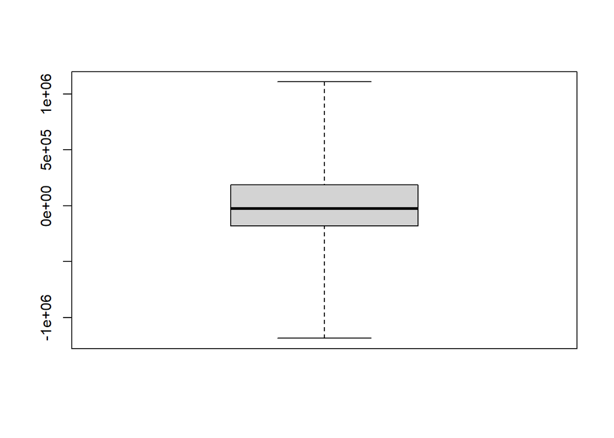

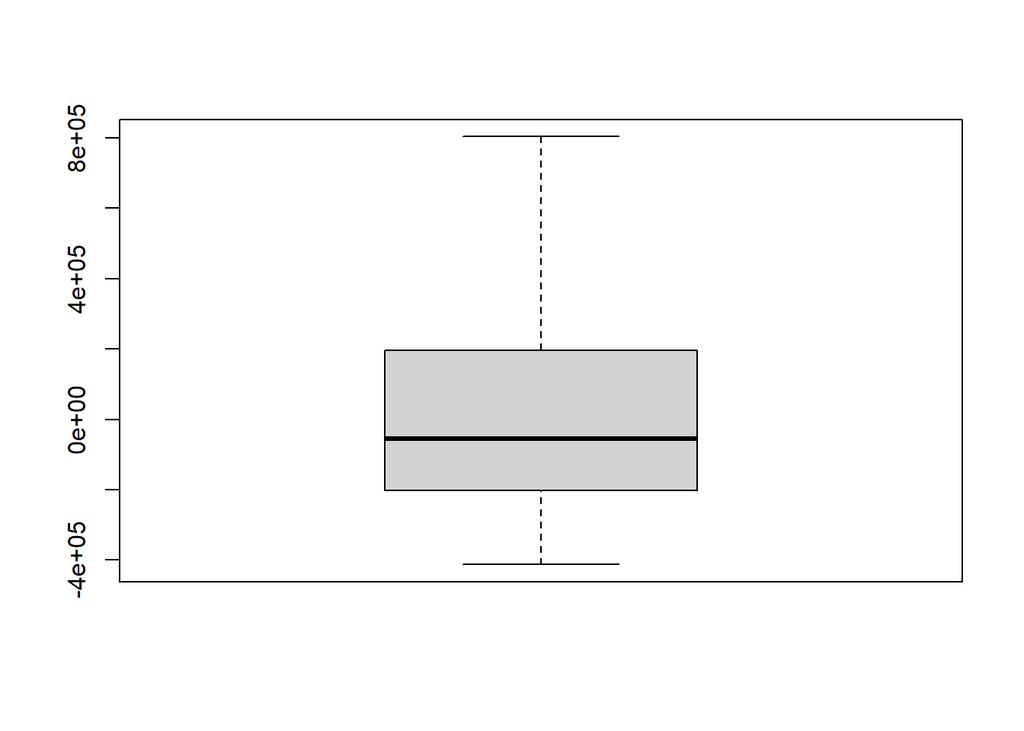

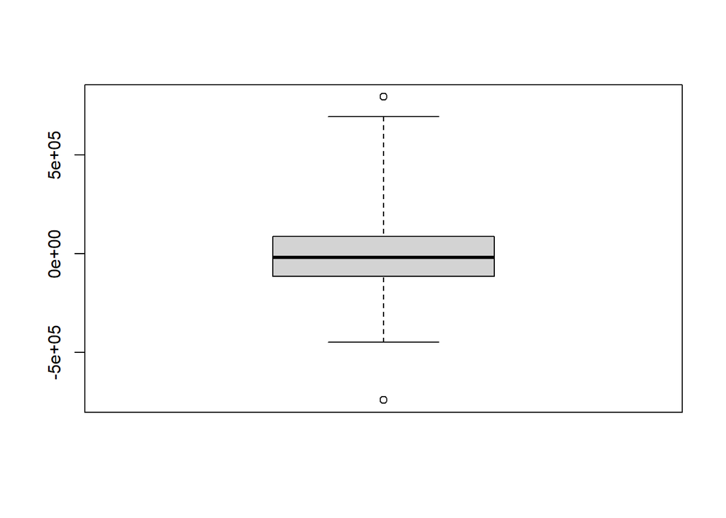

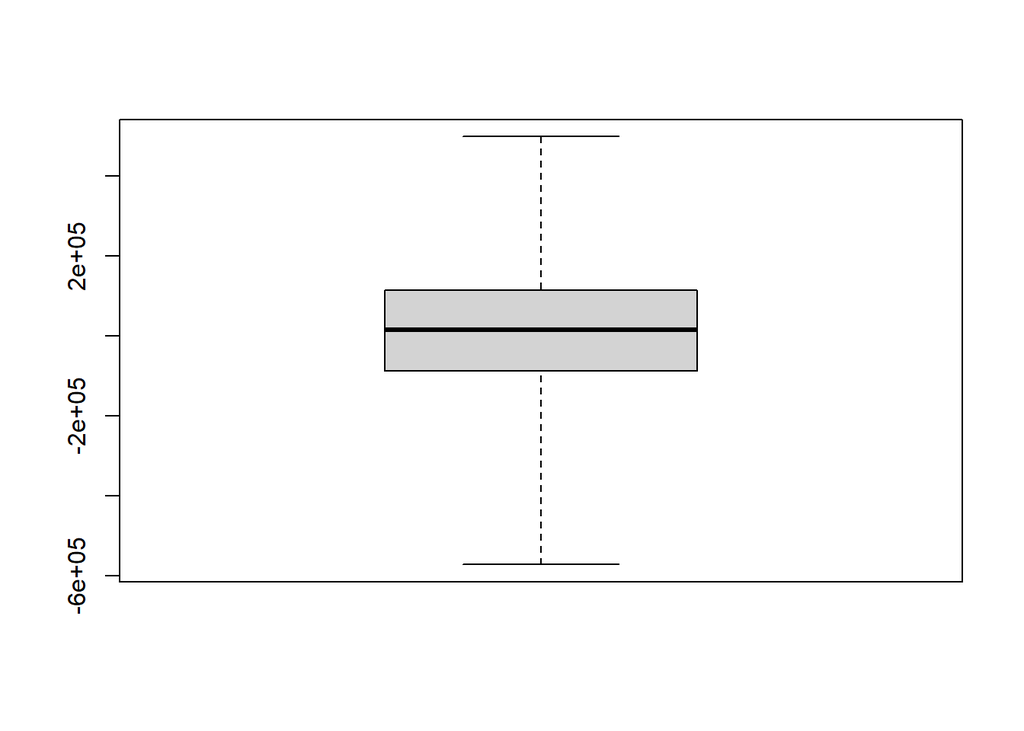

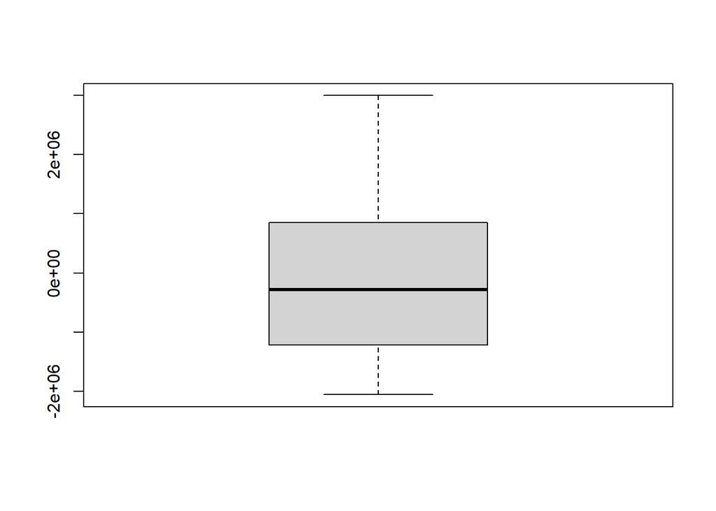

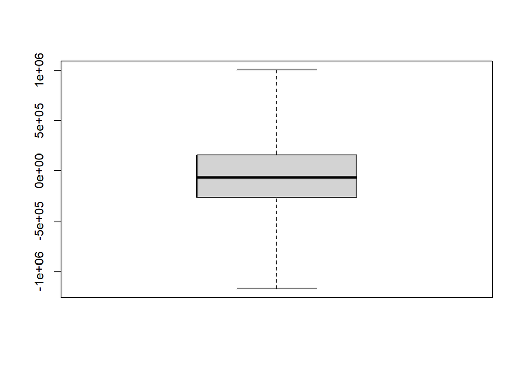

[23 more figures not shown]

```
## [[1]]
## [1] "Removed 8 subjects: hB_RNA_17125, hB_RNA_4761, hB_RNA_4774, hB_RNA_4951, hB_RNA_4961, hB_RNA_4980, hB_RNA_16795, hB_RNA_17155"
##
## [[2]]
## [1] "Pre-QC n=187. Post-QC n=179"
##
## [1] "coercing extreme values to max/min indiviually per gene"
## [1] "number of genes detected with >0 low outliers = 802/18616"
## [1] "number of genes detected with >0 high outliers = 4009/18616"
## [1] "number of observations adjusted for low outliers = 1-20. quantiles=1,1,1,1,20"
## [1] "number of observations adjusted for high outliers = 1-15. quantiles=1,1,1,2,15"
## [1] "completed ##------ Mon May 10 11:39:19 2021 ------##"
## [1] "WARNING: DGE object phenotype data contains missing values"
## [1] "QCd_ydge_BM44"
## [1] "v_BM44"
```

```r
#we want to run each cohort through the QC pipeline
QCpipelineAMPAD <- function(cohort){
  if(str_detect(cohort, "MSBB")){
    cohort <- gsub('MSB', '', cohort)
  }
  print(cohort)
  cohort_ydge_name <-  paste0(cohort, "ydge")
  filename <- paste0("raw_", cohort_ydge_name, ".rds")
  ### read in raw ydge for each dataset
  setwd('./rawYDGE')
  raw_ydge <- readRDS(filename)
  setwd('../')
  ### run through unified QC pipeline, running PCA separately
  PCBYGROUP <- T
  SUBTHRES <- 3
  IQROBSTHRES <- 3
  y <- bulk_qc(ydge=raw_ydge,
               pc.bygroup = PCBYGROUP,
               IQR_sub_threshold = SUBTHRES,
               IQR_obs_threshold = IQROBSTHRES,
               variance.prune = F,
               high.prune = F)

  fileConn<-file(paste0(cohort,"QCresults.txt"))
  writeLines(
    c(paste(t(y$returnparams)[,1],collapse=": "),
      paste(t(y$returnparams)[,2],collapse=": "),
      paste(t(y$returnparams)[,3],collapse=": "),
      paste(t(y$returnparams)[,4],collapse=": "),
      paste(t(y$returnparams)[,5],collapse=": "),
      paste(t(y$returnparams)[,6],collapse=": "),
      paste(t(y$returnparams)[,7],collapse=": "),
      paste(t(y$returnparams)[,8],collapse=": "),
      paste(t(y$returnparams)[,9],collapse=": "),
      paste(y$returnprune),
      paste(y$returnprunehigh),
      paste(y$returnprunevar),
      paste(y$returnsub),
      paste(y$timestamp)),
    fileConn)
  close(fileConn)

  setwd('./QCpipelineResults')
  y_name <-  paste0("QCd_ydge_", cohort)
  y2 <- calcNormFactors(y$YDGE)
  assign(y_name, y2)
  print(y_name)
  saveRDS(y2,file=paste0(y_name, ".rds"))

  v_name <-  paste0("v_", cohort)
  v <- voom(y2)
  assign(v_name, v)
  print(v_name)
  saveRDS(v,file=paste0(v_name, ".rds"))
  setwd('../')
}

#run QC on each cohort
cohorts <- c("ROSMAP", "MAYO", "MSBBM10", "MSBBM22", "MSBBM36", "MSBBM44")
for(cohort in cohorts){
  QCpipelineAMPAD(cohort)
}
```

```r
#load in new cohorts QC-ed data
cohorts <- c("ROSMAP", "MAYO", "MSBBM10", "MSBBM22", "MSBBM36", "MSBBM44")
for(cohort in cohorts){
  if(str_detect(cohort, "MSBB")){
    cohort <- gsub('MSB', '', cohort)
  }
  print(cohort)
  y_name <-  paste0("QCd_ydge_", cohort)
  filename <- paste0(y_name, ".rds")
  setwd('./QCpipelineResults')
  y <- readRDS(filename)
  setwd('../')
  assign(y_name, y)

  v_name <-  paste0("v_", cohort)
  filename <- paste0(v_name, ".rds")
  setwd('./QCpipelineResults')
  voom <- readRDS(filename)
  setwd('../')
  assign(v_name, voom)
  print(v_name)
}
```

```
## [1] "ROSMAP"
## [1] "v_ROSMAP"
## [1] "MAYO"
## [1] "v_MAYO"
## [1] "BM10"
## [1] "v_BM10"
## [1] "BM22"
## [1] "v_BM22"
## [1] "BM36"
## [1] "v_BM36"
## [1] "BM44"
## [1] "v_BM44"
```

This now means we have:

ROSMAP: 597

(So we lost 35 subjects in QC)

MAYO: 147

(So we lost 4 subjects in QC)

MSBB BM10: 209

(So we lost 5 subjects in QC)

MSBB BM22: 181

(So we lost 10 subjects in QC)

MSBB BM36: 161

(So we lost 1 subjects in QC)

MSBB BM44: 179

(So we lost 8 subjectsin QC)

```r
#we want to remove batch effort on each of the cohorts
removeBatchAMPAD <- function(cohort){
  if(str_detect(cohort, "MSBB")){
    cohort <- gsub('MSB', '', cohort)
  }
  print(cohort)
  cohort_QC_ydge_name <-  paste0("QCd_ydge_", cohort)
  QC_filename <- paste0(cohort_QC_ydge_name, ".rds")
  voom_filename <- paste0("v_", cohort, ".rds")
  ### read in QCd data
  setwd('./QCpipelineResults')
  QC_ydge <- readRDS(QC_filename)
  voom <- readRDS(voom_filename)
  setwd('../')
  matrix_name <- paste0(cohort, "_matrix")
  lmod_name <-  paste0("lmod_" ,cohort)
  #set variables to correct class within each voom object
  if (cohort == "ROSMAP"){
    voom$targets <- within(voom$targets,{
      LOAD <- factor(ifelse(Diagnosis=="AD",1,0))
      sex <- as.factor(msex)
    })
  #variables to covary for
  all.covs <- c('lib.size', 'PCT_PF_READS_ALIGNED', 'PCT_CODING_BASES', 'PCT_INTERGENIC_BASES', 'PCT_INTRONIC_BASES', 'PCT_RIBOSOMAL_BASES', 'norm.factors', 'RINcontinuous', 'pmi')
    designvars <- c("msex","age","Batch", "PCT_PF_READS_ALIGNED", "PCT_CODING_BASES","PCT_INTERGENIC_BASES", "PCT_INTRONIC_BASES", "PCT_RIBOSOMAL_BASES", "pmi","LOAD","RINcontinuous")
    batch <- c('Batch')
    Acovs <- voom$targets[,all.covs]

  }
  if (cohort == "MAYO"){
    voom$targets <- within(voom$targets,{
      msex <- as.factor(ifelse(Sex=="MALE",1,0))
      FLOWCELL <- as.factor(FLOWCELL)
      Source <- as.factor(Source)
      AgeAtDeath <- as.numeric(AgeAtDeath)
      LOAD <- factor(ifelse(Tissue.Diagnosis=="TCX.AD",1,0))
      PMI <- as.numeric(impute(voom$targets$PMI,fun = mean))
    })
    #variables to covary for
    all.covs =c('lib.size', 'PCT_PF_READS_ALIGNED', 'PCT_CODING_BASES', 'PCT_INTERGENIC_BASES', 'PCT_INTRONIC_BASES', 'PCT_RIBOSOMAL_BASES', 'norm.factors', 'RIN','PMI')
    designvars <- c("msex","FLOWCELL", "AgeAtDeath","PCT_PF_READS_ALIGNED", "PCT_CODING_BASES","PCT_INTERGENIC_BASES", "PCT_INTRONIC_BASES", "PCT_RIBOSOMAL_BASES", "PMI","LOAD","RIN")
    batch <- c('Source')
    Acovs <- cbind(voom$targets[,all.covs],model.matrix( ~ voom$targets$FLOWCELL-1))

  }
  if(str_detect(cohort, "BM")){
    voom$targets <- voom$targets %>% mutate(ageDeath = gsub('\\+','',ageDeath))
    voom$targets <- within(voom$targets,{
      msex <- as.factor(ifelse(sex=="male",1,0))
      batch <- as.factor(batch)
      TotalReads <- as.numeric(TotalReads)
      Mapped <- as.numeric(Mapped)
      pmi <- as.numeric(pmi)
      AgeAtDeath <- as.numeric(ageDeath)
      LOAD <- factor(ifelse(Tissue.Diagnosis==".AD",1,0))
    })
    #variables to covary for
    all.covs =c("lib.size", "norm.factors","RIN", "rRNA.rate","TotalReads", "Mapped", "pmi")
    designvars <-c("lib.size", "norm.factors", "msex","batch", "AgeAtDeath","RIN", "rRNA.rate","TotalReads", "Mapped", "pmi","LOAD")
    batch <- c('batch')
    Acovs <- cbind(voom$targets[,all.covs],model.matrix( ~ voom$targets$batch - 1))

  }
  setwd('./QCpipelineResults')
  saveRDS(voom, voom_filename)
  setwd('../')
  designtext <- paste("model.matrix( ~ ",paste("voom$targets$",designvars,sep="",collapse=" + ")," )",sep="")
  design <- eval(parse(text=designtext))


  #remove batch effect, without sex and age at death & no design matrix
  cohort_matrix <- removeBatchEffect(voom,
                                     batch = voom$targets[, batch],
                                     covariates= Acovs)

  assign(matrix_name, cohort_matrix)
  setwd('./finalCountMatrices')
  saveRDS(cohort_matrix, file=paste0(matrix_name, ".rds"))
  setwd('../')

  #save lmFit run
  lmod <- lmFit(voom,design= design,method="robust",maxit=10000)
  assign(lmod_name, lmod)
  setwd('./cohortQCMods')
  saveRDS(lmod, file=paste0(lmod_name, ".rds"))

  eb <- eBayes(lmod,robust = T)
  eb_name <- paste0(cohort, "_eb")
  assign(eb_name, eb)
  saveRDS(eb,file=paste0(eb_name, ".rds"))

  coefnum <- grep("LOAD",colnames(eb))
  tt <- topTable(eb,coef=coefnum,20000,sort.by = "none")

  # calculate the standard error of LogFC
  tt$se <- eb$stdev.unscaled[,coefnum]*sqrt(eb$s2.post)

  # format the output to be most informative
  tt$gene <- rownames(tt)
  tt <- tt[order(tt$P.Value,decreasing=F),]

  tt_name <- paste0(cohort, "_tt")
  assign(tt_name, tt)

  # save toptable (tt) of all summary stats
  saveRDS(tt,file=paste0(tt_name, ".rds"))
  setwd('../')

}

#this will give us the final count matrices, lmod and ebayes objects for each cohort
cohorts <- c("ROSMAP", "MAYO", "MSBBM10", "MSBBM22", "MSBBM36", "MSBBM44")
for(cohort in cohorts){
  removeBatchAMPAD(cohort)
}
```

```
## [1] "ROSMAP"
## [1] "MAYO"
## Coefficients not estimable: voom$targets$FLOWCELLBC6178ACXX
```

```
## [1] "BM10"
## Coefficients not estimable: voom$targets$batchK75rC014 voom$targets$batchP60C014 voom$targets$batchP62C014 voom$targets$batchS107B355 voom$targets$batchS108B355 voom$targets$batchS109B355 voom$targets$batchS111B394 voom$targets$batchS112B394
```

```
## [1] "BM22"
## Coefficients not estimable: voom$targets$batchE007C014 voom$targets$batchE2C014 voom$targets$batchE3C014 voom$targets$batchH154B394 voom$targets$batchK75rC014 voom$targets$batchK79C014 voom$targets$batchS112B394 voom$targets$batchS113B355 voom$targets$batchS113B394 voom$targets$batchS114B394 voom…
```

```
## [1] "BM36"
## Coefficients not estimable: voom$targets$batchE007C014 voom$targets$batchK77C014 voom$targets$batchK79C014 voom$targets$batchP19B648 voom$targets$batchS109B355 voom$targets$batchS110B355 voom$targets$batchS111B355 voom$targets$batchS115B355 voom$targets$batchS151B648
```

```
## [1] "BM44"
## Coefficients not estimable: voom$targets$batchB18C014 voom$targets$batchB28C849 voom$targets$batchE007C014 voom$targets$batchE008C189 voom$targets$batchE009C189 voom$targets$batchK79C014 voom$targets$batchK80C014 voom$targets$batchK82C014 voom$targets$batchK85C014
```

```r
#load in new cohorts QC-ed data
cohorts <- c("ROSMAP", "MAYO", "MSBBM10", "MSBBM22", "MSBBM36", "MSBBM44")
for(cohort in cohorts){
  if(str_detect(cohort, "MSBB")){
    cohort <- gsub('MSB', '', cohort)
  }
  print(cohort)
  matrix_name <- paste0(cohort, "_matrix")
  lmod_name <-  paste0("lmod_" ,cohort)

  filename <- paste0(matrix_name, ".rds")
  setwd('./finalCountMatrices')
  matrix <- readRDS(filename)
  setwd('../')
  assign(matrix_name, matrix)

  filename <- paste0(lmod_name, ".rds")
  setwd('./cohortQCMods')
  lmod <- readRDS(filename)
  setwd('../')
  assign(lmod_name, lmod)
}
```

```
## [1] "ROSMAP"
## [1] "MAYO"
## [1] "BM10"
## [1] "BM22"
## [1] "BM36"
## [1] "BM44"
```